# regression_technical

```python
import os
os.chdir('../src')
```

```python
import pandas as pd
import numpy as np
from sklearn import metrics
import matplotlib.pyplot as plt
```

## Regression

Theoretically optimizing the log-return accuracy should be equivalent to optimizing the expected log-returns and thus equivalent to optimizing the returns. Thus, returns-wise it might be a better idea to use regression.

```python
featureset = 'indicators1'

df = pd.read_hdf('../data/features/technical.h5', key=featureset)
df['preds'] = pd.read_hdf('../data/predictions/regression_{}.h5'.format(featureset), key='predictions')
df.preds = df.preds
df = df.dropna()

importances = pd.read_hdf('../data/predictions/regression_{}.h5'.format(featureset), key='importances')
metrics.accuracy_score(df.target > 0, df.preds > 0)
```

```
0.5321079718516962
```

```python
df.preds.std()
```

```
0.17205063579462265
```

```python
s = (df.rolling(100).std().dropna() == 0).sum()
s[s != 0]
```

```
MFI_0.5           7
BBWIDTH_2std    511
dtype: int64
```

```python
importances.sort_values()
```

```
CCI_0.5                -0.166892
STOCH_k                -0.126528
BBANDS_up_0.5std       -0.107407
CCI_2                  -0.101263
STOCHRSI_k_2           -0.081370
BBANDS_down_2std       -0.056023
MINUS_DI_2             -0.053487
APO_2                  -0.053139
STOCHRSI_d_0.5         -0.050865
PPO_0.5                -0.048513
PPO_2                  -0.045451
MFI_0.5                -0.031851
CMO_2                  -0.031641
RSI_2                  -0.031641
AROONOSC_0.5           -0.031298
BBWIDTH_2std           -0.027144
BBWIDTH_0.5std         -0.027144
DX_2                   -0.025787
HT_TREND_/             -0.023411
PLUS_DM_2              -0.023240
AROONOSC_2             -0.021201
NATR_2                 -0.019813
HT_SINE_sine           -0.018770
HT_TRENDMODE           -0.012869
ROCR_2                 -0.011956
STOCH_d                -0.011360
ADOSC_2                -0.010265
MFI_2                  -0.009727
ADX_0.5                -0.009357
ADOSC_0.5              -0.006132
                          ...
HT_DCPERIOD            -0.003009
AROON_down             -0.002281
ROCR_0.5               -0.002216
HT_DCPHASE              0.000171
NATR_0.5                0.002568
DX_0.5                  0.003522
APO_0.5                 0.004646
MOM_0.5                 0.004864
AROON_up                0.008799
SAR_Signal              0.008941
HT_PHASOR_inphase       0.008971
HT_PHASOR_quadrature    0.010715
BBANDS_down_0.5std      0.011832
ADX_2                   0.014461
BOP                     0.019358
HT_SINE_leadsine        0.023015
MINUS_DM_0.5            0.033589
ULTOSC_0.5              0.037310
PLUS_DM_0.5             0.038539
PLUS_DI_2               0.040160
MINUS_DM_2              0.044125
MINUS_DI_0.5            0.047213
WILLR_2                 0.050130
MOM_2                   0.065506
RSI_0.5                 0.083370
CMO_0.5                 0.083370
BBANDS_up_2std          0.120628
EMA/                    0.136828
STOCHRSI_d_2            0.153133
WILLR_0.5               0.213211
Length: 63, dtype: float64
```

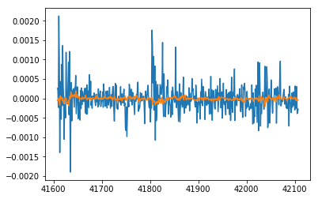

```python
df.target[30000:30500].plot()
(df.preds * df.target.rolling(25).std())[30000:30500].plot()
```

Nice predictor we got here. At least it's not overfitting. The little accuracy performance we got was due to me dividing by the rolling standard deviation.

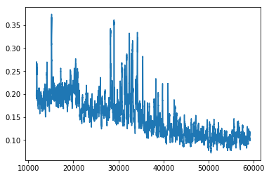

```python
df.preds.rolling(100).std().plot()
```

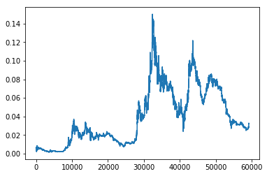

```python
prices = pd.read_json('../data/raw/BTC_ETH.json')
prices.close.plot()
```

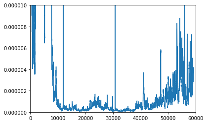

```python
prices['log_diff'] = np.log(prices.close) - np.log(prices.close.shift(-1))
ax = plt.gca(xlim=(1, 60000), ylim=(0, 0.00001))
(np.square(prices.log_diff) / prices.volume).rolling(100).mean().plot()
```

My hypothesis is that total volume in bitcoin and volatility is very correlated, and that the graph above shows that poloniex did have a smaller share of the volume pie in the beginning and at the end, so the quotient doesn't perfectly match up.

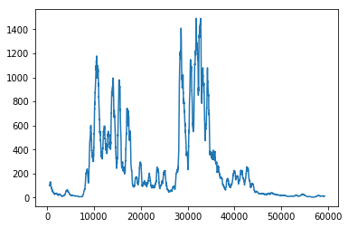

```python
prices.volume.rolling(500).mean().plot()
```

## Proper Normalization

Through which lens can we look at the data such that it has the nicest statistical properties possible? This question is especiallyl crucial for such notoriously noisy and unpredictable data. The goal here is to do regression, but if you look at the regression notebook you will see that the price norms are all over the place and the predictions are very close to the mean. This changes if you divide the target by the rolling standard deviation and you go from 51.4% accuracy on the sign of the prediction to 53.2%. It doesn't matter if you do this to the features.

What we basically want to minimize is the local and global standard deviation of log-diff^2. How does a rolling average affect this?

```
global std: 4.878865602063849
local std: 2.345057301790629
```

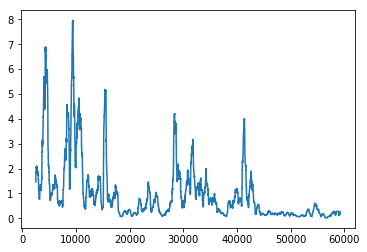

```python
p_squared = np.square(prices.log_diff[2000:] / prices.log_diff[2000:].std())
p_squared.rolling(500).mean().plot() # note the high rolling frame period
print('global std:', pd.Series(p_squared).std())
print('local std:', pd.Series(p_squared).rolling(100).std().mean())
```

```
global std: 1.9862657251083975
local std: 1.9334807337311726
```

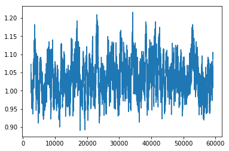

```python
s = prices.log_diff[2000:]
s = s / s.rolling(25).std()
s_squared = pd.Series(np.square(s))
s_squared.rolling(500).mean().plot()

print('global std:', pd.Series(s_squared).std())
print('local std:', pd.Series(s_squared).rolling(100).std().mean())
```

Basically we have removed large norm deviations. But it definetly feel very forced, because we are straight up fabricating the new target. What if we used candles that dependende on the trade volume and not on time? This would seem very intuitive, because price action is **very** dense on the *hype zone*, see volume graph above and it does not compare to the other historical values. Maybe on the days where "nothing happens", one can actually not predict anything and on the extreme days one would profit from a more granular approach. First we granular data of a big chunk of ethereum history and a good estimate for the total volume in this asset class.

```python
a = df[:10]
a.target
b = df[5:20]
a.combine_first(b)
```

|  | target | BBANDS_up_0.5std | BBANDS_down_0.5std | BBWIDTH_0.5std | HT_TREND_/ | EMA/ | SAR_Signal | ADX_0.5 | APO_0.5 | AROON_up | ... | PPO_2 | ROCR_2 | RSI_2 | STOCHRSI_k_2 | STOCHRSI_d_2 | ULTOSC_2 | WILLR_2 | ADOSC_2 | NATR_2 | preds |
| --- | --- | --- | --- | --- | --- | --- | --- | --- | --- | --- | --- | --- | --- | --- | --- | --- | --- | --- | --- | --- | --- |
| 11608 | 0.000082 | False | False | 0.000298 | 0.996189 | 0.992443 | False | 39.423713 | 0.000082 | 57.142857 | ... | -1.839475 | 0.969277 | 42.735499 | 90.652541 | 8.918859e+01 | 51.732165 | -49.515553 | 559.835671 | 1.129223 | 0.205075 |
| 11609 | 0.000253 | False | False | 0.000247 | 0.993160 | 0.989861 | False | 35.570254 | 0.000072 | 50.000000 | ... | -1.841288 | 0.964591 | 41.875333 | 72.470998 | 8.770785e+01 | 49.233225 | -52.727746 | 478.176436 | 1.111532 | -0.008953 |
| 11610 | -0.000216 | False | True | 0.000317 | 0.983005 | 0.981020 | False | 36.833520 | 0.000091 | 42.857143 | ... | -1.846187 | 0.956199 | 39.337832 | 24.199228 | 6.244092e+01 | 49.749049 | -65.251989 | 370.087703 | 1.144292 | 0.012586 |
| 11611 | 0.000128 | False | False | 0.000269 | 0.991778 | 0.990331 | False | 38.725967 | 0.000092 | 35.714286 | ... | -1.857074 | 0.968222 | 42.425523 | 77.490274 | 5.805350e+01 | 52.705077 | -53.793103 | 474.228244 | 1.160683 | 0.418740 |
| 11612 | 0.000005 | False | False | 0.000239 | 0.987256 | 0.986142 | False | 39.423254 | 0.000097 | 28.571429 | ... | -1.892152 | 0.975477 | 41.138705 | 53.003238 | 5.156425e+01 | 52.206604 | -60.583554 | 478.317377 | 1.154992 | -0.019543 |
| 11613 | 0.000000 | False | True | 0.000000 | 0.988048 | 0.986837 | False | 40.490430 | 0.000036 | 21.428571 | ... | -1.934235 | 0.991048 | 41.088220 | 56.689237 | 6.239425e+01 | 54.507229 | -60.848806 | 456.623862 | 1.134895 | 0.042632 |
| 11614 | 0.000009 | False | True | 0.000000 | 0.989797 | 0.987675 | False | 38.845330 | -0.000024 | 14.285714 | ... | -1.962864 | 0.994577 | 41.088220 | 56.689237 | 5.546057e+01 | 53.774255 | -60.848806 | 396.263735 | 1.122845 | -0.143098 |
| 11615 | 0.000152 | False | True | 0.000000 | 0.991856 | 0.988124 | False | 36.141586 | -0.000070 | 7.142857 | ... | -1.984150 | 0.987064 | 40.991167 | 0.000000 | 3.779282e+01 | 52.977731 | -61.324668 | 316.701620 | 1.122097 | -0.212954 |
| 11616 | 0.000089 | False | True | 0.000000 | 0.988360 | 0.983150 | False | 37.166287 | -0.000054 | 0.000000 | ... | -1.984154 | 0.988502 | 39.357175 | 0.000000 | 1.889641e+01 | 50.578602 | -69.389920 | 262.732493 | 1.132360 | -0.048544 |
| 11617 | -0.000173 | False | True | 0.000206 | 0.986819 | 0.980864 | False | 33.955588 | -0.000103 | 7.142857 | ... | -1.974413 | 0.980655 | 38.428462 | 0.000000 | 2.178998e-13 | 44.942795 | -74.105040 | 118.522048 | 1.161958 | -0.485548 |
| 11618 | -0.000059 | True | False | 0.000000 | 0.995327 | 0.988613 | False | 30.370919 | -0.000101 | 0.000000 | ... | -1.920548 | 0.991986 | 41.226938 | 100.000000 | 3.333333e+01 | 43.804099 | -63.757477 | -30.183656 | 1.182065 | -0.195873 |
| 11619 | 0.000328 | True | False | 0.000000 | 0.998728 | 0.991567 | False | 26.208830 | -0.000107 | 42.857143 | ... | -1.889636 | 1.001100 | 42.156135 | 100.000000 | 6.666667e+01 | 41.140276 | -58.668197 | -220.188837 | 1.189461 | -0.210026 |
| 11620 | -0.000048 | False | True | 0.000235 | 0.986095 | 0.979694 | False | 27.711831 | -0.000114 | 100.000000 | ... | -1.862386 | 0.991246 | 38.631389 | 5.443801 | 6.848127e+01 | 40.978423 | -71.197649 | -532.048626 | 1.230400 | 0.130800 |
| 11621 | 0.000026 | False | False | 0.000256 | 0.988405 | 0.982799 | False | 29.000118 | -0.000120 | 92.857143 | ... | -1.868551 | 0.997493 | 39.400183 | 26.067744 | 4.383718e+01 | 38.817281 | -61.097259 | -654.549819 | 1.216241 | 0.203289 |
| 11622 | -0.000348 | False | False | 0.000274 | 0.987788 | 0.982905 | False | 27.849208 | -0.000109 | 85.714286 | ... | -1.870025 | 0.995199 | 39.124908 | 14.001532 | 1.517103e+01 | 36.672683 | -63.395225 | -811.427975 | 1.213820 | -0.040316 |
| 11623 | -0.000959 | True | False | 0.000322 | 1.002155 | 0.997201 | False | 23.980953 | -0.000072 | 78.571429 | ... | -1.803760 | 0.992656 | 44.508383 | 100.000000 | 4.668976e+01 | 40.140030 | -32.625995 | -751.981624 | 1.213965 | 0.273276 |
| 11624 | -0.000040 | True | False | 0.001012 | 1.040545 | 1.033668 | False | 28.317644 | 0.000040 | 71.428571 | ... | -1.624706 | 1.042150 | 55.703449 | 100.000000 | 7.133384e+01 | 49.079352 | -2.271437 | 46.616263 | 1.266276 | 0.218943 |
| 11625 | 0.000110 | True | False | 0.001204 | 1.040683 | 1.032934 | False | 33.133007 | 0.000135 | 64.285714 | ... | -1.400331 | 1.036437 | 56.086654 | 100.000000 | 1.000000e+02 | 47.344993 | -14.556041 | 510.836537 | 1.315250 | -0.147615 |
| 11626 | 0.000004 | False | False | 0.001124 | 1.034565 | 1.026608 | False | 37.260460 | 0.000275 | 57.142857 | ... | -1.207757 | 1.039305 | 54.736251 | 92.038535 | 9.734618e+01 | 47.212337 | -19.893256 | 549.492163 | 1.321382 | -0.067679 |
| 11627 | -0.000183 | False | False | 0.000751 | 1.032810 | 1.024718 | False | 38.067732 | 0.000406 | 50.000000 | ... | -1.062342 | 1.024170 | 54.692799 | 87.961459 | 9.333333e+01 | 49.409780 | -20.063076 | 699.123280 | 1.310935 | 0.204615 |

20 rows × 65 columns